# Ievads ggplot2 grafiskajā sistēmā

## Pamatojums

- ggplot2 pakete atšķiras no citām diagrammu veidošanas paketēm ar to, ka tās pamatā ir noteikta ”gramatika” (Wilkinson, 2005. Grammar of graphics)
- Sistēma sastāv no vairākām atseviškām komponentēm, kuras var dažādā veidā kombinēt
- Ir iespēja veidot jaunus diagrammu veidus, kas parāda Jums aktuālo problēmu

## Papildus informācija

Oficiālā dokumentācija:

http://docs.ggplot2.org/current/

R attēlu ”recepšu grāmata”:

http://www.cookbook-r.com/Graphs/

Jautājumi un atbildes:

http://stackoverflow.com/questions/tagged/ggplot2

## Sistēmas komponentes

`ggplot2` attēli tiek veidoti no slāņiem:

- **data** – informācija, kuru vēlas attēlot
- **aes** jeb **aesthetics** – datu attēlošanas veids – simbolu veids, krāsa utt
- **geom** – ģeometriskie objekti (līnija, punkti, poligoni), kurus reāli redz
- **stats** – statistiskās transformācijas datiem
- **scale** – nodrošina datu vērtību attēlojumu atbilstoši izvēlētajiem datu parādīšanas veidam (aesthetics), kā arī veido leģendas un asis
- **coord** – koordināšu sistēma, ko izmanto diagrammā
- **facet** – nosaka kā sadalīt datus pa atsevišķām diagrammām

## geom veidi

- `geom_point()` – zīmē punktus, lai veidotu izkliedes diagrammu
- `geom_smooth()` – zīmē līniju, kas izlīdzina datus, kā arī šīs līnijas standartkļūdu
- `geom_boxplot()` – veido vērtībamplitūdas (box-and-whisker) diagrammu
- `geom_path()` un `geom_line()` – zīmē līniju, kas savieno punktus
- `geom_abline()`,`geom_hline()`,`geom_vline()` – zīmē līnijas
- `geom_histogram()` – veido histogrammu
- `geom_density()` – veido blīvuma diagrammu
- `geom_bar()` – veido joslu jeb stabiņu diagrammu

## Paketes

```r
# Pamatpakete attēlu atveidošanai
if (!require("ggplot2") )  install.packages("ggplot2")
library(ggplot2)
# Pakete nepieciešama, ja jāizmanto funkcija unit() (mērvienības)
if (!require("grid") )  install.packages("grid")
library(grid)
# Pakete, kurā ir papildus skalas un to transformācijas
if (!require("scales") )  install.packages("scales")
library(scales)
```

## Dati

```r
dati <- read.csv(file="../Dati/augi.csv",header=TRUE,sep=",",dec=".")
head(dati)
```

```
##   gaisma stress lapas garums
## 1   zema    nav   264     91
## 2   zema    nav   200     80
## 3   zema    nav   225     88
## 4   zema    nav   268    109
## 5   zema    nav   215     76
## 6   zema    nav   241     96
```

## Attēlu veidošana

`ggplot2` sistēmā attēlus veido ar divām funkcijām - `qplot()` un `ggplot()`. Pirmā funkcija paredzēta ātrākai attēla izveidošanai, bet vienlaicīgi tai ir daudz mazāka iespēja tikt modificētai. `ggplot()` funkcijas gadījumā ir visas iespējas veikt katra elementa modifikāciju.

Funkcijā `ggplot()` kā pirmais arguments ir jānorāda datu tabulu (data frame), no kurienes ņemt datus, tad iekšā ir funkcija `aes()`, kur attiecīgi norāda x un y vērtības (atdalītas ar komatu).

`ggplot2` sistēmā **NAV** jāizmanto mainīgo pieraksts ar `$` zīmi.

## geom_point()

Lai izveidotu punktu (izkliedes) attēlu, `ggplot()` norāda datu tabulu un x/y vērtības, un tam pieskaita nepieciešamo `geom_...` veidu.

```r
ggplot(dati, aes(garums, lapas)) + geom_point()
```

[output not shown]

## Izskata maiņa

Lai mainītu punktu, līniju, poligonu izskatu (krāsu, lielumu, formu, caurspīdīgumu), ir divas iespējas:

1. Ja izskatam ir jābūt vienādam visiem elementiem, piemēram, visi punkti sarkani, tad atbilstošais arguments ir jāievieto `geom_...` funkcijā ārpus `aes()` iekavām un jānorāda atbilstošā vērtība.
2. Ja izskatam ir jāmainās atbilstoši kādam mainīgajam (piemēram, katrai sugai cita krāsa), tad atbilstošais arguments ir jāievieto funkcijā `geom_...` vai `ggplot()`, bet OBLIGĀTI iekšā `aes()` iekavām un kā vērtība jānorāda mainīgā nosaukums.

## Faktori un skaitliskas vērtības

1. Ja pie izskata (krāsas, caurspīdīguma, lieluma) maiņas argumenta norāda skaitliskas vērtības, tad atbilstošie elementi mainās kā gradients (no mazākās uz lielāko vērtību).
2. Ja pie izskata maiņas argumenta norāda faktoru (vai skaitli, kas pārvērsts par faktoru), tad atbilstošie elementi mainās kā diskrētas (atsevišķas) vērtības.

## geom_point()

Krāsa kā gradients

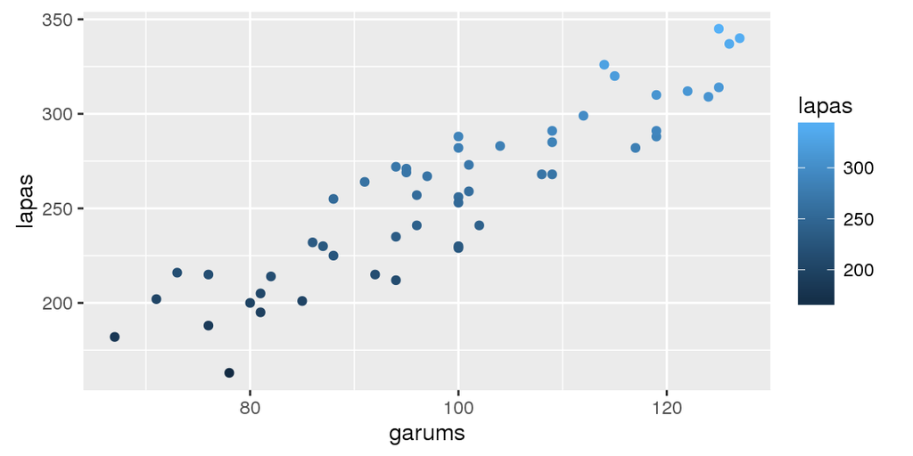

```r
ggplot(dati, aes(garums, lapas,color=lapas)) + geom_point()
```

## geom_point()

Krāsa kā diskrēta vērtība

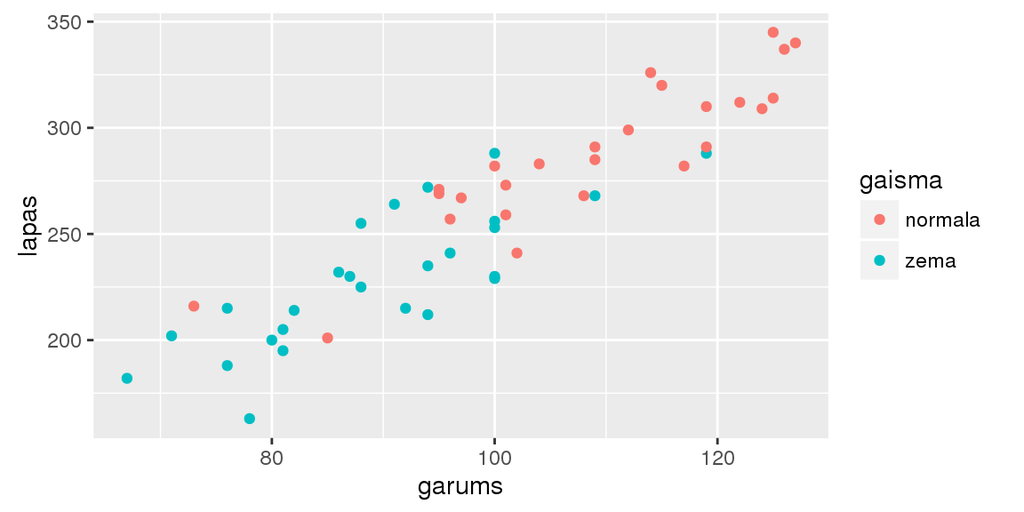

```r
ggplot(dati, aes(garums, lapas,color=gaisma)) + geom_point()
```

## geom_point()

Forma kā diskrēta vērtība

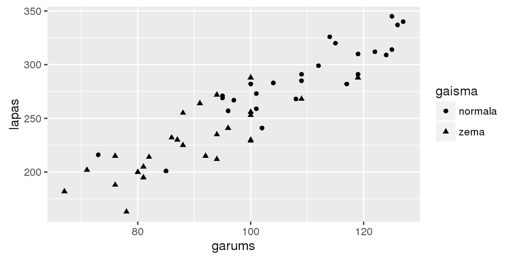

```r
ggplot(dati, aes(garums, lapas,shape=gaisma)) + geom_point()
```

## geom_point()

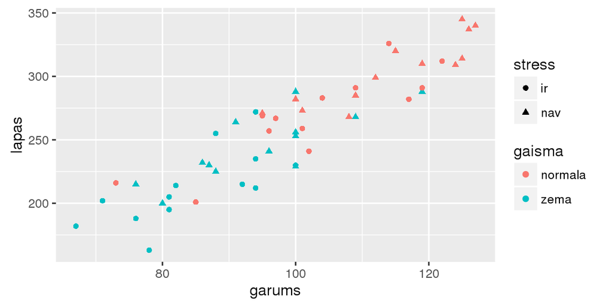

```r
ggplot(dati, aes(garums, lapas,color=gaisma,shape=stress)) + geom_point()
```

## geom_point()

Krāsa un izmērs, kas noteikts visiem punktiem vienāds

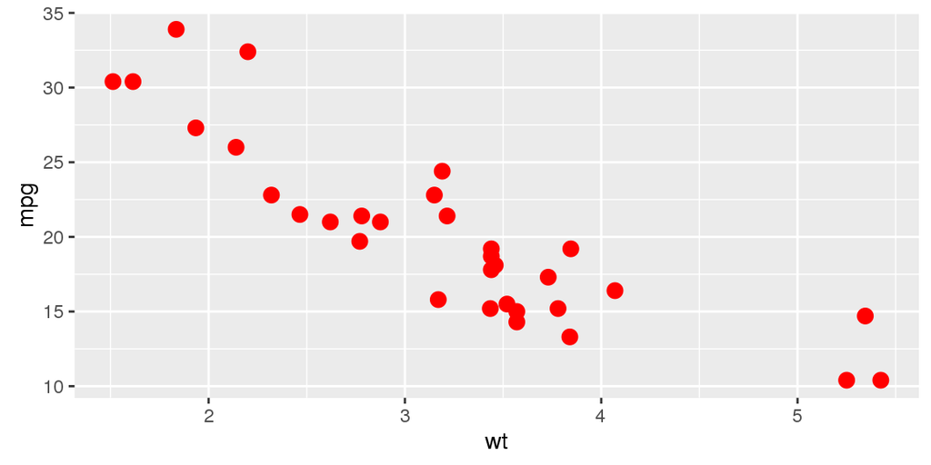

```r
ggplot(mtcars, aes(wt, mpg)) + geom_point(colour = "red", size = 3)
```

## geom_bar()

Veidojot stabiņu diagrammu (`geom_bar()`) ir nepieciešamas tikai x vērtības (faktors), jo atkārtojumu skaitu nosaka automātiski.

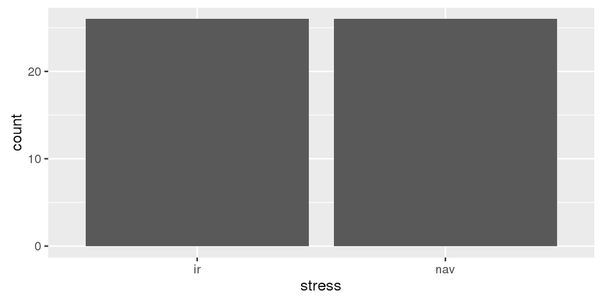

```r
ggplot(dati, aes(stress))+geom_bar()
```

## geom_bar()

Stabiņam ir iespējams noteik krāsu (līniju, kas ir apkārt) un aizpildījumu (`fill=`).

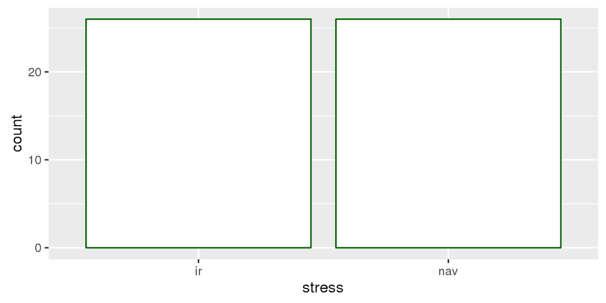

```r
ggplot(dati, aes(stress)) + geom_bar(fill="white", colour="darkgreen")
```

## geom_bar()

Ja aizpildījumu norāda kā mainīgo `aes()`, pēc noklusējuma stabiņi tiek sadalīti pa daļām atbilstoši mainīgajam.

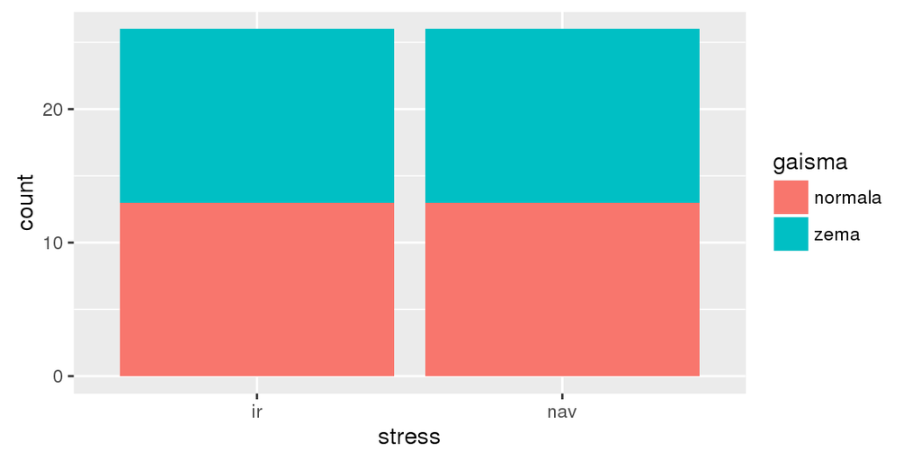

```r
ggplot(dati, aes(stress,fill=gaisma)) + geom_bar()
```

## geom_bar()

Lai iegūtu stabiņus, kas sadalīti pēc mainīgā un būtu novietoti blakus, papildus jānorāda arguments `position="dodge"`.

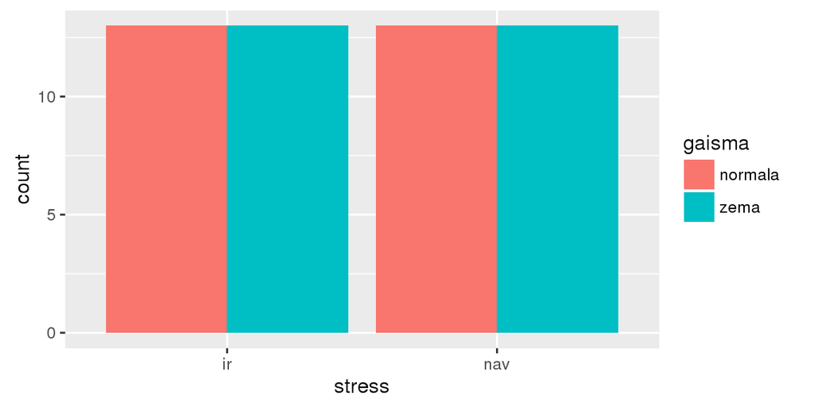

```r
ggplot(dati, aes(stress,fill=gaisma)) + geom_bar(position="dodge")
```

## geom_bar()

Ja y vērtības stabiņu attēlam jau ir zināmas, tad kā papildus arguments jānorāda `stat="identity"`.

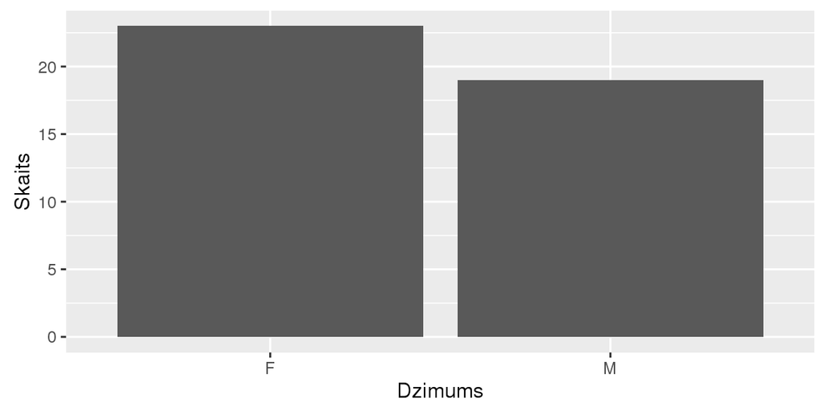

```r
df<-data.frame(Dzimums=c("F","M"),Skaits=c(23,19))
ggplot(df,aes(Dzimums,Skaits))+geom_bar(stat="identity")
```

## geom_boxplot()

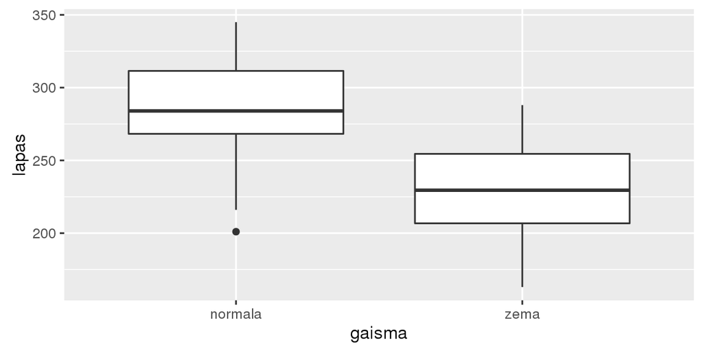

```r
ggplot(dati, aes(gaisma, lapas)) + geom_boxplot()
```

## geom_boxplot()

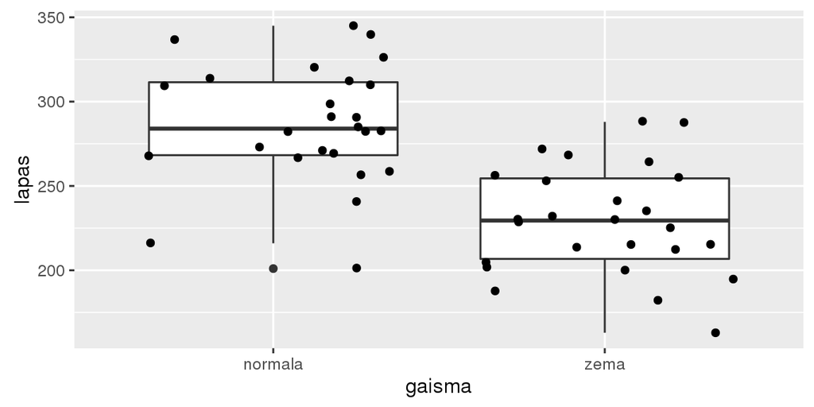

```r
ggplot(dati, aes(gaisma, lapas)) + geom_boxplot() + geom_jitter()
```

## geom_boxplot

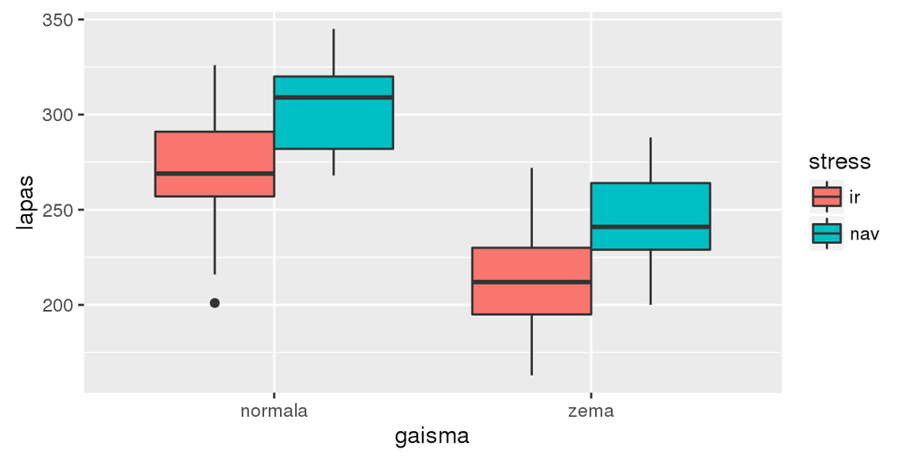

```r
ggplot(dati, aes(gaisma, lapas,fill=stress)) + geom_boxplot()
```

## geom_hline()

Horizontālu līniju pievienošanai izmanto funkciju `geom_hline()`, kurai kā argumentu norāda `yintercept=`, kas var būt gan iekļauts `aes()`, gan ārpus tā.

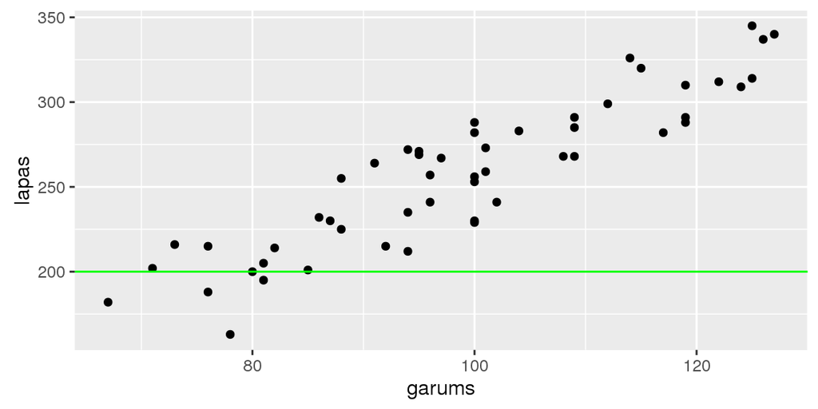

```r
ggplot(dati, aes(garums,lapas)) + geom_point()+geom_hline(yintercept=200,color="green")
```

## geom_vline

Vertikālu līniju pievienošanai izmanto `geom_vline()` un argumentu `xintercept=`.

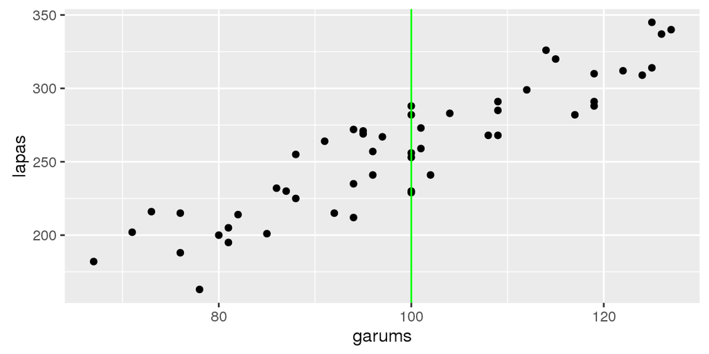

```r
ggplot(dati, aes(garums,lapas)) + geom_point()+geom_vline(xintercept=100,color="green")
```

## geom_line()

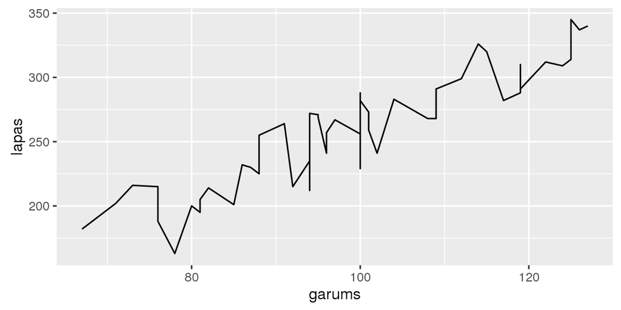

```r
ggplot(dati, aes(garums,lapas)) + geom_line()
```

## geom_line()

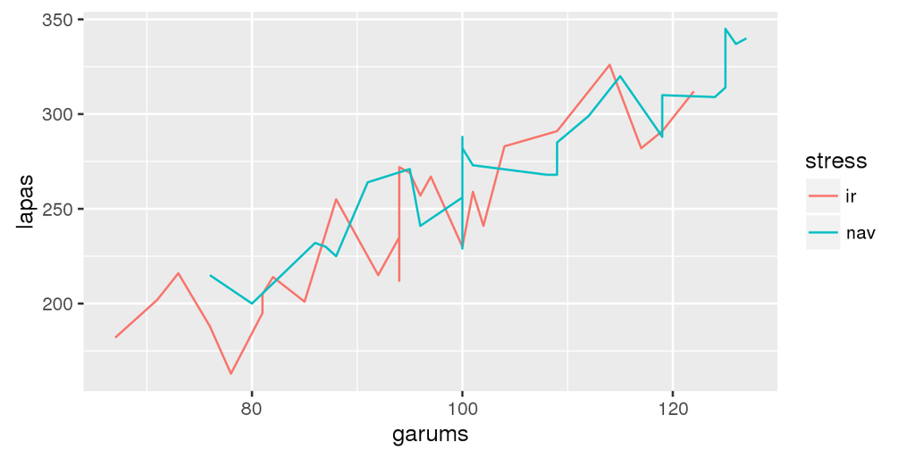

```r
ggplot(dati, aes(garums,lapas,color=stress)) + geom_line()
```

## geom_line()

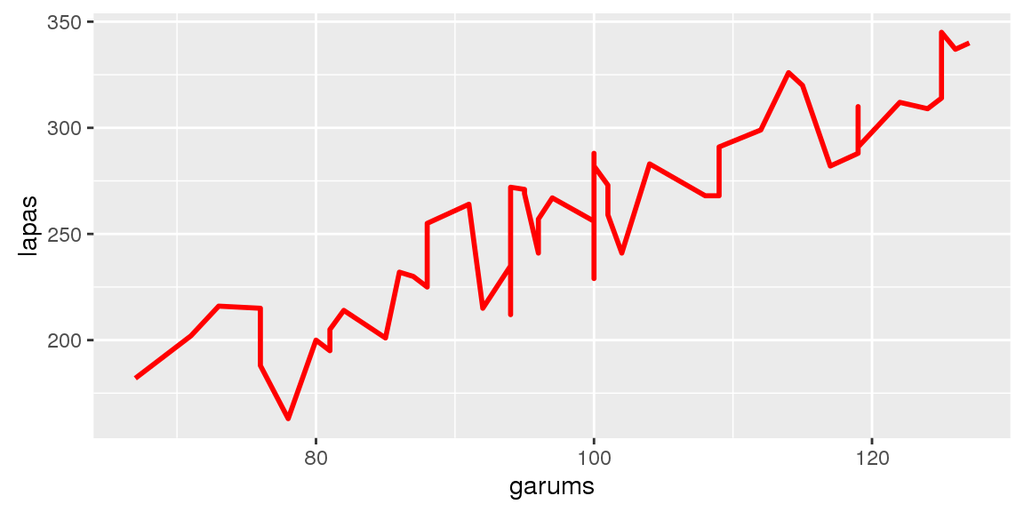

```r
ggplot(dati, aes(garums,lapas)) +  geom_line(colour = "red", size = 1)
```

## geom_smooth()

Ar funkciju `geom_smooth()` var pievienot "trenda" līniju kopā ar ticamības intervālu. Izlīdzinātās līnijas veids tiek noteikts automātiski.

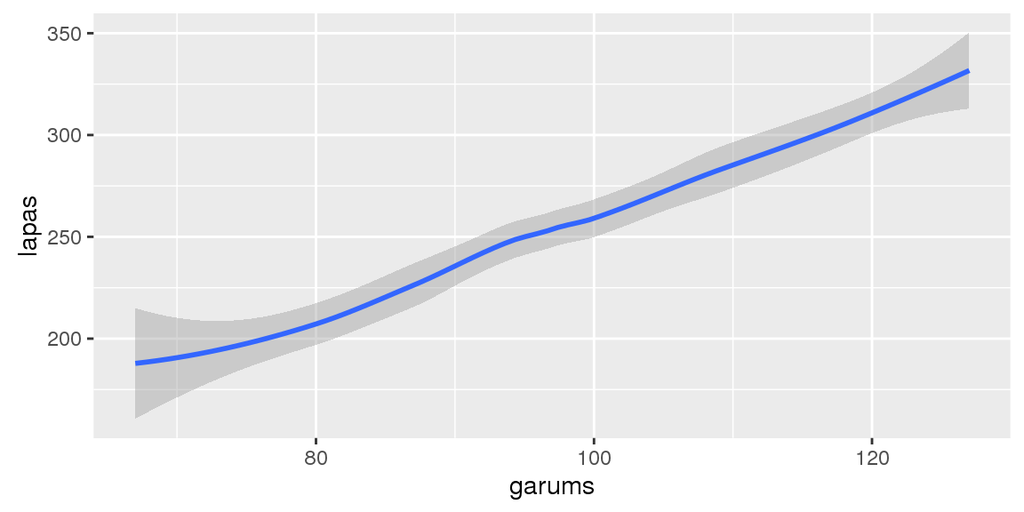

```r
ggplot(dati,aes(garums,lapas)) + geom_smooth()
```

## stat_smooth()

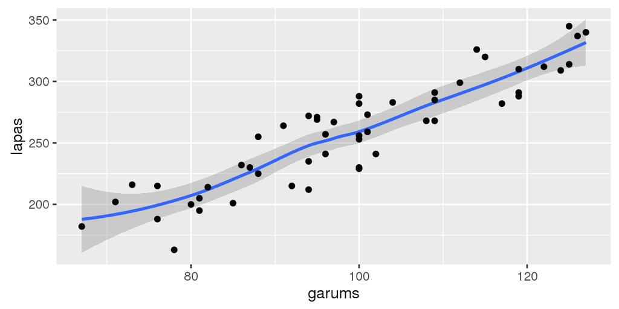

```r
ggplot(dati,aes(garums,lapas)) + geom_smooth() + geom_point()
```

## geom_smooth()

Ar argumentu `se=FALSE` var noņemt ticamības intervālu.

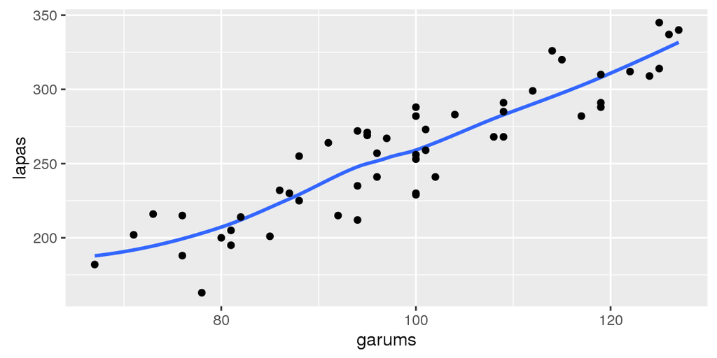

```r
ggplot(dati,aes(garums,lapas)) + geom_smooth(se = FALSE) + geom_point()
```

## geom_smooth()

Ja nepieciešams pievienot tieši lineāru trendu, tad jālieto arguments `method="lm"`.

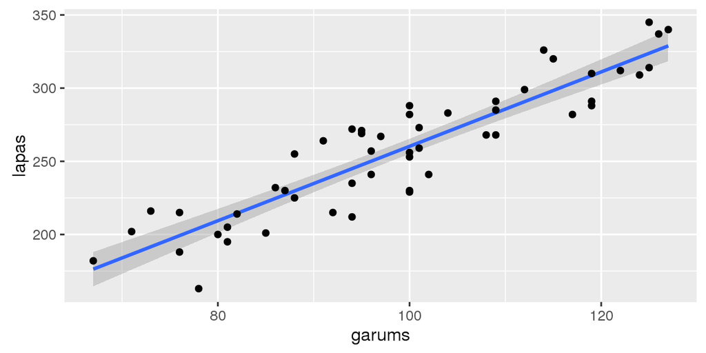

```r
ggplot(dati,aes(garums,lapas))+ geom_smooth(method = "lm") + geom_point()
```

## geom_smooth()

Nosakot krāsu (līnijai) vai aizpildījumu (ticamības intervāliem) atkarībā no mainīgā, trenda līnijas parādīsies katram līmenim atsevišķi.

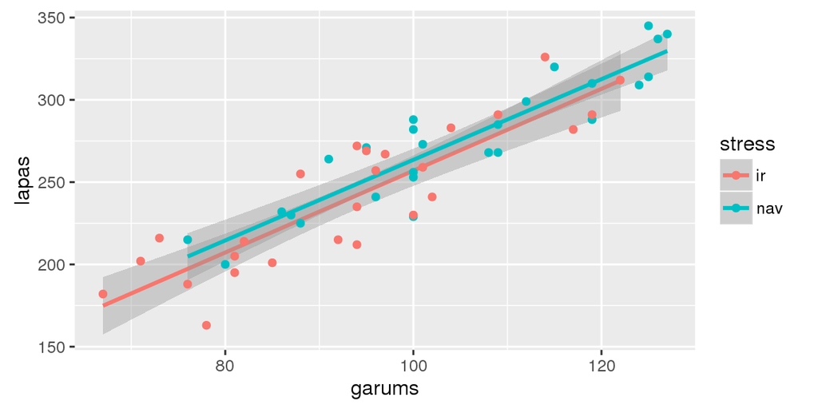

```r
ggplot(dati,aes(garums,lapas,color=stress))+ geom_smooth(method = "lm") + geom_point()
```

## Skalas

Izmantojot funkcijas `scale_..._...()` var mainīt ne tikai x un y asu noformēju un veidu, bet arī ietekmēt visus citus atribūtus, kas tiek noteikti izmantojot `aes()`: krāsas, lielumus, punktu formas, līniju veidus, apzīmējumu caurspīdīgumu.

Skalu piemēri:

- `scale_x_discrete()`,`scale_y_discrete()`
- `scale_x_continuous()`,`scale_y_continuous()`
- `scale_colour_discrete()`,`scale_colour_continuous()`,`scale_colour_grey()`, `scale_colour_gradient()`
- `scale_fill_discrete()`,`scale_fill_continuous()`,`scale_fill_grey()`, `scale_fill_gradient()`

## Skalas

Skalu piemēri:

- `scale_linetype_discrete()`,`scale_linetype_continuous()`, `scale_linetype_manual()`,`scale_linetype_identity()`
- `scale_x_log10()`,`scale_x_reverse()`,`scale_x_sqrt()`

## Skalas

Skalām var mainīt sekojošos parametrus:

- name - nosaukums
- breaks - dalījuma vietas
- labels - apzīmējumi dalījuma vietās
- limits - vērtību diapozons
- values - lietotāja definētās krāsas/līniju veidi/simbolu veidi - izmanto tikai ar `scale_..._manual()`

## scale_colour_discrete()

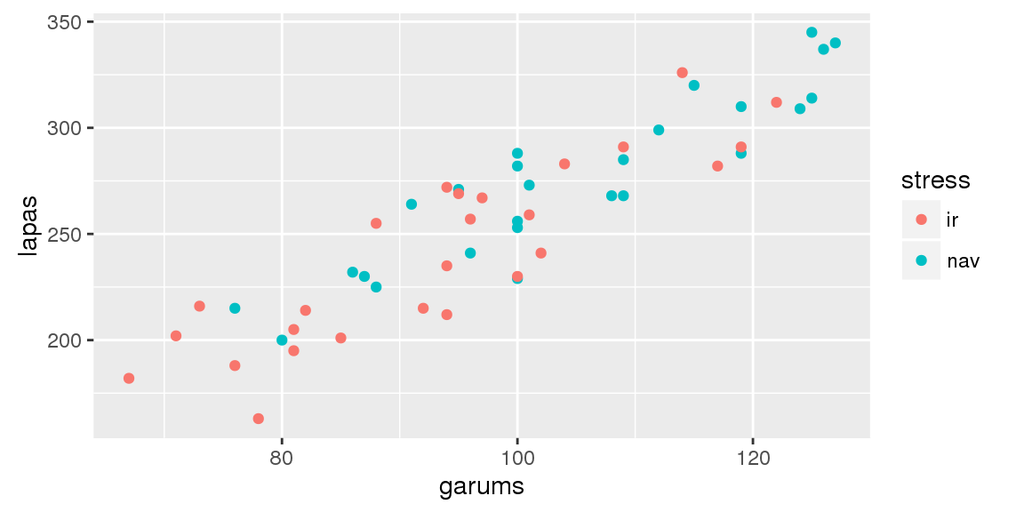

```r
ggplot(dati,aes(garums, lapas, color=stress)) + geom_point()
```

## scale_colour_discrete()

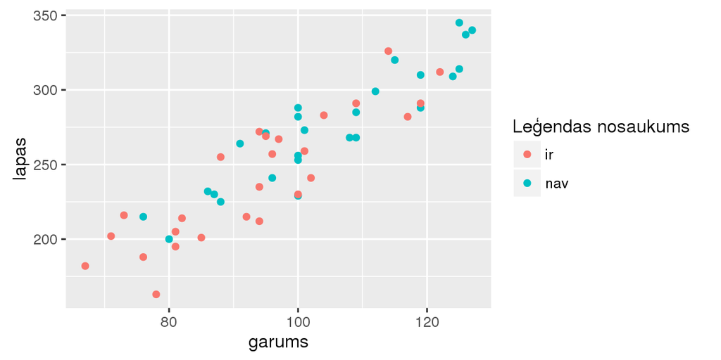

```r
ggplot(dati,aes(garums, lapas, color=stress)) + geom_point() +
      scale_colour_discrete("Leģendas nosaukums")
```

## scale_colour_grey()

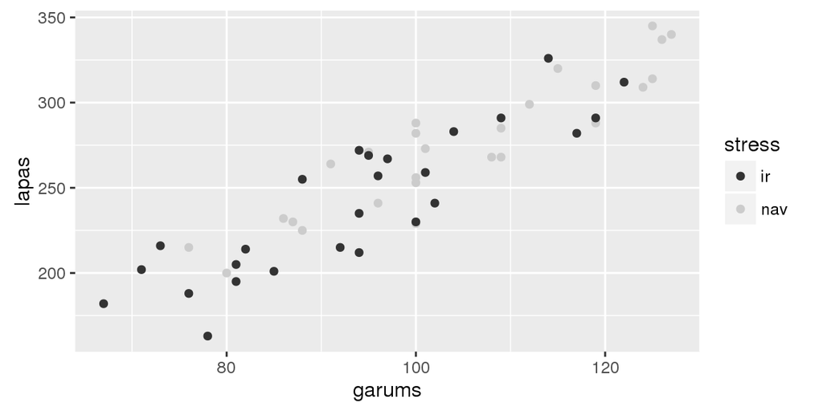

```r
ggplot(dati,aes(garums, lapas, color=stress)) + geom_point() +
      scale_colour_grey()
```

## scale_colour_manual()

Izmantojot `scale_..._manual()` ir iespējams izraudzīties paša definētās vērtības (to skaitam jāatbilst līmeņu skaitam).

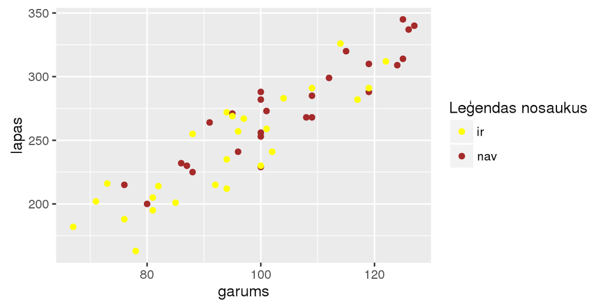

```r
ggplot(dati,aes(garums, lapas, color=stress)) + geom_point()  +
      scale_colour_manual("Leģendas nosaukus",values = c("yellow","brown"))
```

## scale_colour_manual()

Lai mainītu līmeņu nosaukumus leģendā, jāizmanto argumentu `labels=`.

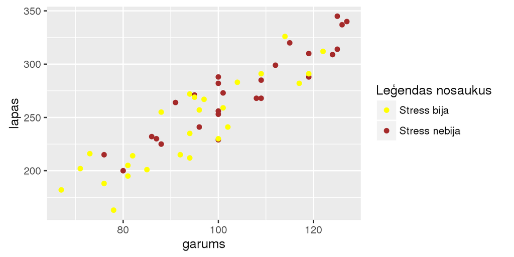

```r
ggplot(dati,aes(garums, lapas, color=stress)) + geom_point()  +
      scale_colour_manual("Leģendas nosaukus",values = c("yellow","brown"),
                          labels=c("Stress bija","Stress nebija"))
```

## scale_continuous()

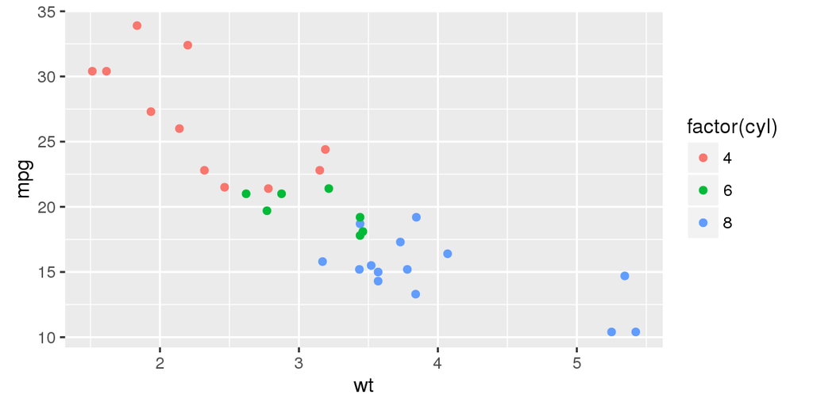

```r
ggplot(mtcars, aes(x = wt, y = mpg,color=factor(cyl))) + geom_point()
```

## scale_continuous()

Skaitliskām vērtībām izmanto `scale_.._continuous()`.

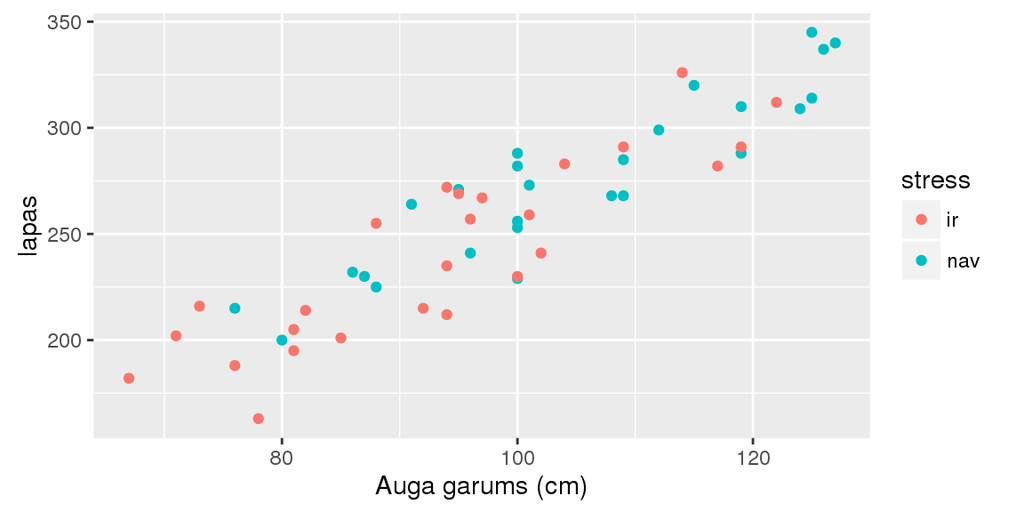

```r
ggplot(dati,aes(garums, lapas, color=stress)) + geom_point() +
      scale_x_continuous("Auga garums (cm)")
```